# Quality Control

Quality control of 476 *Streptococcus mutans* genomes.

## CheckM

CheckM assesses the parameters genome completeness and genome contamination. According to its inbuilt marker lineages, 475 genomes were classified as “o__Lactobacillales (UID544),” while 1 genome could not be classified further than “k__Bacteria (UID203).” Genomes with completenss less than 90% and/or contamination larger than 5% were deemed “poor quality” and excluded from further analysis:

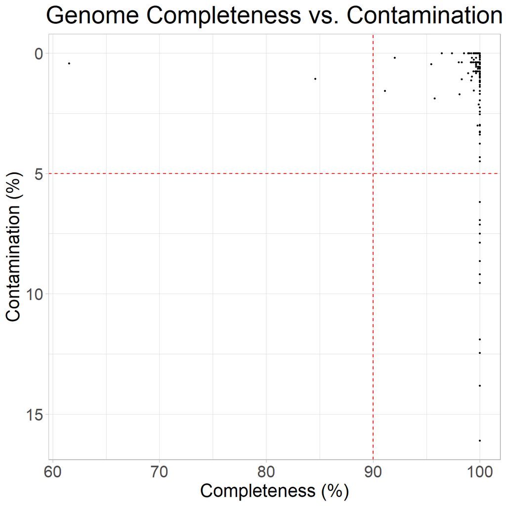

According to these parameters 2 genomes were excluded based on completeness and 12 based on contamination.

## GTDB-Tk

Taxonomic classification of all genomes: All genomes were classified as d__Bacteria;p__Bacillota;c__Bacilli;o__Lactobacillales;f__Streptococcaceae;g__Streptococcus;s__Streptococcus mutans

## QUAST

Assessment of genome size, number of contigs per genome, and N50 (fraction of contigs that combine to be more than 50% of the genome).

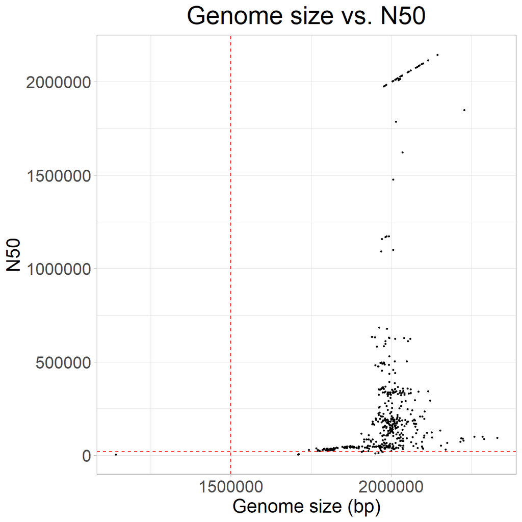

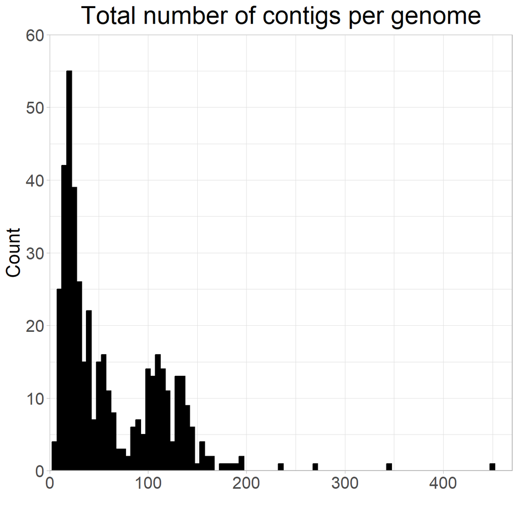

1 genome with a size lower than 1.5 Mb and 6 genomes with a N50 value lower than 20,000 were excluded from further analysis.

In total 18 genomes were exluded from further analysis based on these parameters.